# Note-rmarkdown

Weiquan Luo

Updated by 2021-01-24

### Use of this document

This is a study note for using $rmarkdown $ package to generate rmarkown’s site. For more details on the study material see: (https://bookdown.org/yihui/rmarkdown/rmarkdown-site.html)

supplemental materials:

- [How to Write Math formulas](http://www.statpower.net/Content/310/R%20Stuff/SampleMarkdown.html)
- [How to Write special symbols using LaTeX](https://artofproblemsolving.com/wiki/index.php/LaTeX:Symbols)
- [List of Greek letters and math symbols in Latex](https://www.overleaf.com/learn/latex/List_of_Greek_letters_and_math_symbols)

Note: some code chunk in this document include syntax for code chunk, I mask the syntax by a backslash to avoid the issue of rendering this document, so ignore the `\` in those code chunk.

# 1 Workflow

the rmarkdown package had provided a simple site generator

## 1.1 Elements

There is a list of Common elements need to be created manually:

| elements | Description |
| --- | --- |
| `_site.yml` (required) | configuration file. Editable for navigation bar. Connect all fileS includinG `footer.html`, `styles.css` and all `*.Rmd` therefore the resulting `*.html`, |
| `index.Rmd` (required) | first Rmd files, usually become the Homepage of the website |
| `about.Rmd` | additioanal information for the website |
| `footer.html` | footer |
| `styles.css` | text style |

## 1.2 Build

- Preview Current: Click `Knit` button or `rmarkdown::render_site("about.Rmd")` to render and preview the current page of the individual `.Rmd` file
- Preview All: Run `rmarkdown::render_site()` on Rstudio Console command line, the following will occur
  - rendered all `*.Rmd` and `*.md` into HTML, but not `_*.Rmd` at the current working directory,
  - generated HTML files and any supporting files (e.g., CSS and JavaScript) are copied into an output directory (_site by default)
- however, that Markdown files beginning with `_` are not rendered. This is a convention to designate files that are to be included by top level Rmd documents as child documents

## 1.3 Clean

To clean up all files generated by rendering your site's Markdown documents, including knitr's `*_cache` directories:

`rmarkdown::clean_site(preview = TRUE)`: list which files will be removed `rmarkdown::clean_site()`: actually remove the files

## 1.4 knitr caching

If your website is time consuming to render, you may want to enable knitr's caching during the development of the site, so that you can more rapidly preview.

- To enable caching for an individual chunk, add the `cache = TRUE` chunk option to enable caching for an individual chunk `{r, cache = TRUE}`
- To enable caching for an entire document, add `cache = TRUE` in `knitr::opts_chunk$set()` in the `{r setup}` chunk.

# 2. Common elements

## 2.1 Site Structure and Style

Typically when creating a website, there are various common elements you want to include on all pages (e.g., output options, CSS styles, header and footer elements, etc.). Here are additions in three files to the example above to make use of common elements:

### 2.1.1 `_site.yml`

```
name: "my-website"
navbar:
  title: "My Website"
  left:
    - text: "Home"
      href: index.html
    - text: "About"
      href: about.html
output:
  html_document:
    theme: cosmo
    highlight: textmate
    include:
      after_body: footer.html
    css: styles.css
```

It can can be used to define a advance navigation bar for your website

```
name: "my-website"
navbar:
  title: "My Website"
  type: inverse
  left:
    - text: "Home"
      icon: fa-home
      href: index.html
    - text: "About"
      icon: fa-info
      href: about.html
    - text: "More"
      icon: fa-gear
      menu:
        - text: "Heading 1"
        - text: "Page A"
          href: page-a.html
        - text: "Page B"
          href: page-b.html
        - text: "---------"
        - text: "Heading 2"
        - text: "Page C"
          href: page-c.html
        - text: "Page D"
          href: page-d.html
  right:
    - icon: fa-question fa-lg
      href: https://example.com
```

### 2.1.2 `footer.html`

```html
<p>Copyright &copy; 2016 Skynet, Inc. All rights reserved.</p>
```

### 2.1.3 `styles.css`

```
blockquote {
  font-style: italic
}
```

## 2.2 Rmd partials

You may have common fragments of R Markdown that you want to share across pages within your site. To share Rmd fragments, you should name them with a leading underscore (_), and then include them within their parent Rmd document using the child chunk option. For example:

### 2.2.1 `about.Rmd`

```
---
title: "About This Website"
---

More about this website.
```

### 2.2.2 `_session-info.Rmd`

may add some program to add seesioninfo

````
Session information:

\```{r}
sessionInfo()
\```
````

## 2.3 R scripts

If you have R code that you would like to share across multiple R Markdown documents within your site, you can create an R script (e.g., utils.R) and source it within your Rmd files. For example:

```
---
title: "sourcing utils.R"
---

source("utils.R")
```

# 3. Graphic

This section introduce how to insert graphs or figures from local and online to `.Rmd`.

## 3.1 Local Image

Add a R chunk to run the following to insert a local image.

````html
\```{r, echo=FALSE, fig.cap="A caption", out.width = '100%'}
\knitr::include_graphics("temp.png")
\```
````

## 3.1 Online Image

Or using a online image by doing the following.

```html
<center>
![A caption](https://www.95visual.com/sites/default/files/images/inline/file_format_chart.png){
width=20% }
</center>
```

# 4. Output

## 4.1 Format

### 4.1.1 `.HTML` with table

```
---
title: "Note-rmarkdowns site generator"
author: "Weiquan Luo"
date: "2021-01-24"
output:
  html_document:
    toc: true
    theme: united
---
```

### 4.1.2 Github `.md`

```
---
title: "ggplot2 Extension for Fun"
author: "Weiquan Luo"
date: "2021-01-24"
output: rmarkdown::github_document
always_allow_html: yes
---
```

## 4.2 `.R` with Code only

```r
knitr::purl("file.Rmd")
```

# 5. use python3 engine in rmarkdown

The $reticulate$ package provides a comprehensive set of tools for interoperability between Python and R. The package includes facilities for translation between R and Python. $reticulate$ embeds a Python session within your R session, enabling seamless, high-performance interoperability. If you are an R developer that uses Python for some of your work or a member of data science team that uses both languages, reticulate can dramatically streamline your workflow!

When calling into Python, R data types are automatically converted to their equivalent Python types. When values are returned from Python to R they are converted back to R types. Types are converted as follows:

data type convertion between R and Python

| R | Python | Examples |
| --- | --- | --- |
| Single-element | vector Scalar | 1, 1L, TRUE, “foo” |
| Multi-element vector | List | c(1.0, 2.0, 3.0), c(1L, 2L, 3L) |
| List of multiple | types Tuple | list(1L, TRUE, “foo”) |
| Named list | Dict | list(a = 1L, b = 2.0), dict(x = x_data) |
| Matrix/Array | NumPy ndarray | matrix(c(1,2,3,4), nrow = 2, ncol = 2) |
| Data Frame | Pandas DataFrame | data.frame(x = c(1,2,3), y = c(“a”, “b”, “c”)) |
| Function | Python function | function(x) x + 1 |
| NULL, TRUE, FALSE | None, True, False | NULL, TRUE, FALSE |

(source: https://rstudio.github.io/reticulate/)

## 5.1 apply python3 engine

```r
# use python3 engine
library(reticulate)
use_python("/usr/local/bin/python3")
```

```r
library(dplyr)
library(purrr)
iris %>% head %>% knitr::kable(format = "markdown")
```

| Sepal.Length | Sepal.Width | Petal.Length | Petal.Width | Species |
| --- | --- | --- | --- | --- |
| 5.1 | 3.5 | 1.4 | 0.2 | setosa |
| 4.9 | 3.0 | 1.4 | 0.2 | setosa |
| 4.7 | 3.2 | 1.3 | 0.2 | setosa |
| 4.6 | 3.1 | 1.5 | 0.2 | setosa |
| 5.0 | 3.6 | 1.4 | 0.2 | setosa |
| 5.4 | 3.9 | 1.7 | 0.4 | setosa |

## 5.2 Data from R to Python environment

```python
# import r object dat to python
iris = r.iris
# python code
iris2 = iris
x = iris2.iloc[:,:4]
y = iris2.iloc[:,4]
```

```python
# This chunk is python code !!!
import pandas as pd # data structure
import seaborn as sns # visualization
from sklearn.ensemble import RandomForestClassifier # algorithm
from sklearn.model_selection import cross_val_score # target function for Bayesian optimization
from bayes_opt import BayesianOptimization # Bayesian optimization

# Bayesian optimization
def rf_cv(n_estimators, min_samples_split, max_features, max_depth):
    val = cross_val_score(RandomForestClassifier(n_estimators=int(n_estimators),
                                                 min_samples_split=int(min_samples_split),
                                                 max_features=min(max_features, 0.999),
                                                 max_depth=int(max_depth),
                                                 random_state=2),
                          x, y, cv=5).mean()
    return val
rf_bo = BayesianOptimization(rf_cv,
                            {'n_estimators': (10, 250),
                             'min_samples_split': (2, 25),
                             'max_features': (0.1, 0.999),
                             'max_depth': (5, 15) } ) # object for Bayesian optimization

rf_bo.maximize() # optimizing
```

```
## |   iter    |  target   | max_depth | max_fe... | min_sa... | n_esti... |
## -------------------------------------------------------------------------
## |  1        |  0.9533   |  7.676    |  0.142    |  4.293    |  168.5    |
## |  2        |  0.9533   |  12.63    |  0.4374   |  5.438    |  195.4    |
## |  3        |  0.9667   |  5.414    |  0.5805   |  10.9     |  55.77    |
## |  4        |  0.9467   |  9.858    |  0.4605   |  23.94    |  180.0    |
## |  5        |  0.9533   |  12.47    |  0.282    |  19.62    |  143.2    |
## |  6        |  0.9667   |  6.938    |  0.5907   |  11.99    |  55.72    |
## |  7        |  0.96     |  15.0     |  0.999    |  2.0      |  10.0     |
## |  8        |  0.9667   |  15.0     |  0.999    |  2.0      |  86.98    |
## |  9        |  0.9667   |  6.198    |  0.7046   |  24.52    |  80.39    |
## |  10       |  0.96     |  5.079    |  0.9945   |  2.501    |  249.8    |
## |  11       |  0.9533   |  15.0     |  0.1      |  2.0      |  65.81    |
## |  12       |  0.96     |  5.586    |  0.999    |  12.82    |  96.05    |
## |  13       |  0.96     |  5.188    |  0.9776   |  22.48    |  64.68    |
## |  14       |  0.96     |  5.0      |  0.7243   |  13.67    |  44.05    |
## |  15       |  0.96     |  15.0     |  0.2494   |  16.1     |  83.56    |
## |  16       |  0.9533   |  15.0     |  0.1      |  2.0      |  96.81    |
## |  17       |  0.96     |  10.74    |  0.6497   |  2.341    |  82.8     |
## |  18       |  0.96     |  5.395    |  0.8366   |  25.0     |  86.02    |
## |  19       |  0.9667   |  8.359    |  0.5024   |  24.87    |  75.63    |
## |  20       |  0.96     |  5.081    |  0.2101   |  20.12    |  75.43    |
## |  21       |  0.9533   |  13.18    |  0.4486   |  24.48    |  79.16    |
## |  22       |  0.96     |  5.907    |  0.114    |  11.66    |  51.98    |
## |  23       |  0.9667   |  5.562    |  0.5304   |  12.62    |  58.39    |
## |  24       |  0.9467   |  7.327    |  0.2677   |  8.731    |  58.14    |
## |  25       |  0.96     |  5.344    |  0.2527   |  13.63    |  56.83    |
## |  26       |  0.9667   |  6.745    |  0.6631   |  24.76    |  78.42    |
## |  27       |  0.96     |  7.691    |  0.1      |  23.39    |  77.01    |
## |  28       |  0.96     |  5.511    |  0.3178   |  23.74    |  78.8     |
## |  29       |  0.9667   |  5.359    |  0.5109   |  11.98    |  57.07    |
## |  30       |  0.9667   |  14.47    |  0.8922   |  3.746    |  86.36    |
## =========================================================================
```

```python
res = pd.DataFrame(rf_bo.res)
```

## 5.3 Data from Python to R environment

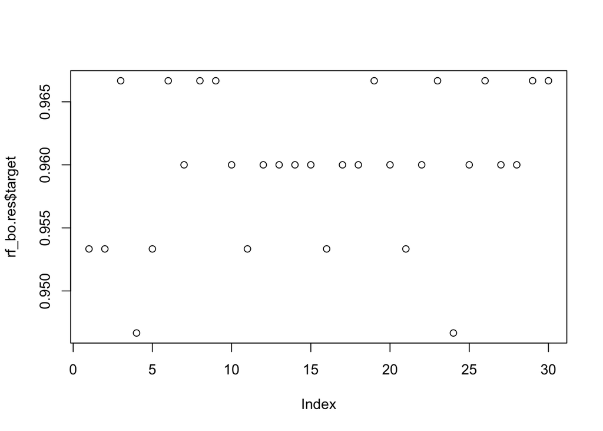

```r
# import python object dat to r
rf_bo.res <- py$res
# r code
plot(rf_bo.res$target)
```